# Introdução ao software R: Aplicações a Ciência Florestal

Fernando M. Haesbaert

22 setembro, 2021

Material elaborado para o VIII Semana Acadêmica de Engenharia Florestal e II Simpósio da Pós-Graduação em Ciências Florestais e Ambientais.  
Realizado de 21 a 23 de setembro de 2021.

[figure not shown]

# 1 Instalação e utilização do Software R e RStudio

Instalação e utilização do [Software R](http://cran.r-project.org/)

Instalação e utilização do Software [RStudio](https://www.rstudio.com/products/rstudio/download/)

RStudio é um ambiente de desenvolvimento integrado (IDE) para R. Inclui um console, editor de realce de sintaxe que oferece suporte à execução direta de código, bem como ferramentas para plotagem, histórico, depuração e gerenciamento de espaço de trabalho [[RStudio]](https://www.rstudio.com/products/rstudio/download/).

# 2 Comandos básicos:

## 2.1 Help

```r
help(sqrt)
help(package="ggplot2")
```

## 2.2 Verificando o conteúdo do diretório

```r
dir() #Listando os objetos.
```

```
##  [1] "dados.txt"
##  [2] "Dicas de Materiais - R Aplicado na Engenharia Florestal.docx"
##  [3] "Introdução ao software R_ Aplicações a Ciência Florestal.pdf"
##  [4] "Introdução ao Software R_Florestal_Prof. Fernando.pptx"
##  [5] "Introdução ao Software R_Florestal_Prof. Fernando_Modelo.pdf"
##  [6] "Introdução ao Software R_Florestal_Prof. Fernando_Modelo.pptx"
##  [7] "IntroRFlorest.html"
##  [8] "IntroRFlorest.log"
##  [9] "IntroRFlorest.Rmd"
## [10] "IntroRFlorest.tex"
## [11] "inventario.xlsx"
## [12] "its-rotating-tree-segmented.gif"
## [13] "levantamento.xlsx"
## [14] "linguagem-r-para-inventario-florestal.pdf"
## [15] "Livro_IntroducaoaoR_AplicacoesFlorestais.pdf"
## [16] "nome do gráfico.tif"
## [17] "Script_Intro_R_Florestal.R"
## [18] "tecmadeira.txt"
## [19] "tecmadeira.xlsx"
```

# 3 Instalação e utilização de pacotes

Listar os Pacotes disponíveis no ambiente R (instalados e disponíveis).

```r
(.packages())
```

```
## [1] "stats"     "graphics"  "grDevices" "utils"     "datasets"  "methods"
## [7] "base"
```

Listar os Pacotes disponíveis em seu computador (instalados e não disponíveis).

```r
head(.packages(all.available=TRUE),20)
```

```
##  [1] "abind"         "ade4"          "agricolae"     "AlgDesign"
##  [5] "aplpack"       "arm"           "askpass"       "assertthat"
##  [9] "backports"     "base64enc"     "bbmle"         "bdsmatrix"
## [13] "BH"            "BiodiversityR" "bit"           "bit64"
## [17] "blob"          "brew"          "brio"          "broom"
```

Para disponibilizar um pacote instalado para uso.

```r
library(ggplot2) # ou require("ggplot2")
```

Para instalar pacotes a partir do CRAN. Será solicitado o CRAN, use o mais próximo.

```r
install.packages("ggplot2")
```

Depois de instalar é preciso carregar (tornar disponível para uso)

```r
library(ggplot2)
library(readxl)
```

## 3.1 A partir do GITHUB

Vamos usar de exemplo o pacote `gganatogram`, disponível em https://github.com/jespermaag/gganatogram

```r
devtools::install_github("https://github.com/jespermaag/gganatogram")
```

Depois de instalar é preciso carregar (tornar disponível para uso)

```r
library(gganatogram)
```

Ajuda para uso do pacote

```r
help("gganatogram")
```

Carregando alguns pacotes que iremos utilizar no decorrer desse minicurso

```r
library(tidyverse)
```

# 4 Funcionalidades Básicas

## 4.1 Atribuições

Salvando o valor `2` no objeto `a`.

```r
a <- 2
```

Avaliando o conteúdo contido no objeto `a`

```r
a
```

```
## [1] 2
```

Observe que o nome dos objetos deve começar com uma letra.

```r
a^2 # potência
```

```
## [1] 4
```

```r
b <- a^2
a = 5
a
```

```
## [1] 5
```

```r
A <- 1 # O R diferencia letras maiúsculas e minúsculas
A
```

```
## [1] 1
```

```r
a
```

```
## [1] 5
```

```r
2 -> a
a
```

```
## [1] 2
```

```r
nome <- "Fernando" # Texto entre aspas
arvore <- "Parkia platycephala"
a <- 2*4
a
```

```
## [1] 8
```

```r
a <- (2*sqrt(16-4*2)-(3*4))
a
```

```
## [1] -6.343146
```

```r
a <- round(a,4) #arredondamento
aa <- round(a,2)
abs(aa) #módulo
```

```
## [1] 6.34
```

```r
a <- (abs(round(a,2)))
a
```

```
## [1] 6.34
```

```r
3+4
```

```
## [1] 7
```

```r
9/3
```

```
## [1] 3
```

```r
sqrt(81)
```

```
## [1] 9
```

```r
log(100)
```

```
## [1] 4.60517
```

```r
log(2.718282)
```

```
## [1] 1
```

```r
log(0.00000000001,10)
```

```
## [1] -11
```

```r
log(100,10)
```

```
## [1] 2
```

```r
15==15
```

```
## [1] TRUE
```

```r
verifica <- 5>2
pi
```

```
## [1] 3.141593
```

```r
sin(0)
```

```
## [1] 0
```

```r
sin(3.141593)
```

```
## [1] -3.464102e-07
```

```r
round(sin(3.141593),5)
```

```
## [1] 0
```

```r
sin(pi)
```

```
## [1] 1.224606e-16
```

```r
round(sin(pi),5)
```

```
## [1] 0
```

```r
cos(pi)
```

```
## [1] -1
```

```r
exp(1)
```

```
## [1] 2.718282
```

## 4.2 Operações e operadores aritméticos no R

| Operadores | Nome | Operações |
| --- | --- | --- |
| + | Somatório | 2+3 |
| * | Multiplicação | 4*9 |
| / | Divisão | 20/5 |
| - | Subtração | 32-10 |
| ^ ou ** | Potenciação | 5^3 |
| %% | Resto inteiro da divisão | 10%%3 |
| %/% | Parte inteira da divisão | 10%/%3 |

## 4.3 Operadores lógicos

[output not shown]

# 5 Tipo de Objetos

Tudo no R são objetos. Um objeto é simplesmente um nome que guarda um valor. Para criar um objeto, utilizamos o operador `<-` ou também o sinal `=`. Tipos de objetos: vetores, matrizes e arrays, data-frames, listas e funções.  
Os tipos básicos de objetos do Rsão: vetores; matrizes e arrays; data-frames; listas e funções.  
Os quatro primeiros tipos são objetos que armazenam dados e que diferem entre si na forma da armazenar e operar com os dados.  
O último (função) é um tipo objeto especial que recebe algum “input” e produz um “output”.  
Usamos as funções do tipo `is.*()` para testar se um objeto é de um determinado tipo. Estas funções são `is.vector()`, `is.matrix()`, `is.array()`, `is.data.frame()`, `is.list()`, `is.function()`.

## 5.1 Classes dos Objetos

Classe de um objeto é muito importante dentro do R. É a partir dela que as funções e operadores conseguem saber o que fazer com um objeto.  
Para criar texto no R, colocamos os caracteres entre aspas. As aspas servem para diferenciar nomes (objetos, funções, pacotes) de textos (letras e palavras). Os textos são muito comuns em variáveis categóricas e são popularmente chamados de strings no contexto de programação.  
Para saber a classe de um objeto usamos a função `class(nome-do-objeto)`.

```r
class(a)
```

```
## [1] "numeric"
```

```r
class(arvore)
```

```
## [1] "character"
```

```r
class(verifica)
```

```
## [1] "logical"
```

## 5.2 Vetores

`c()` c de concatenação  
Vetores são o tipo básico e mais simples de objeto para armazenar dados no R.  
O R é uma linguagem vetorial, e portanto capaz de operar vetores e matrizes diretamente sem a necessidade de “loops”, como por exemplo em códigos C e/ou Fortran.  
Vejamos algumas operações com vetores.  
Os colchetes `[ ]` são usados para indicar seleção de elementos.  
As funções `rep()`, `seq()` e o símbolo `:` são usadas para facilitar a criação de vetores que tenham alguma lei de formação.  
Os vetores podem ser numéricos ou de caracteres. Entretanto há mais um tipo importante de objeto: os fatores.

```r
x <- c(2.5,3,5,2,3) #c = concatenar
x
```

```
## [1] 2.5 3.0 5.0 2.0 3.0
```

```r
a <- 7
x <- c(2.5,a,5,2,3)
x
```

```
## [1] 2.5 7.0 5.0 2.0 3.0
```

```r
x^2
```

```
## [1]  6.25 49.00 25.00  4.00  9.00
```

```r
seq(0,30,5)
```

```
## [1]  0  5 10 15 20 25 30
```

```r
y <- seq(10,1,-1)
y
```

```
##  [1] 10  9  8  7  6  5  4  3  2  1
```

```r
y <- (1:5)
y
```

```
## [1] 1 2 3 4 5
```

```r
y <- (5:1)
y
```

```
## [1] 5 4 3 2 1
```

```r
y <- c((5:1),(1:5),5,7,3)
y
```

```
##  [1] 5 4 3 2 1 1 2 3 4 5 5 7 3
```

```r
y <- sort(y) #ordenar valores
d <- c(x,y)
d
```

```
##  [1] 2.5 7.0 5.0 2.0 3.0 1.0 1.0 2.0 2.0 3.0 3.0 3.0 4.0 4.0 5.0 5.0 5.0 7.0
```

```r
length(y) # contar número de elementos
```

```
## [1] 13
```

```r
rep(8,3) #repetição
```

```
## [1] 8 8 8
```

```r
e <- rep(8,3)
e
```

```
## [1] 8 8 8
```

```r
repetições <- rep(1:3,4)
repetições
```

```
##  [1] 1 2 3 1 2 3 1 2 3 1 2 3
```

```r
x2 <- pi * 10^(-1:3)
x2
```

```
## [1]    0.3141593    3.1415927   31.4159265  314.1592654 3141.5926536
```

```r
x2 <- round(x2, 2) #arredondamento
x2[3]
```

```
## [1] 31.42
```

```r
x2[2:4]
```

```
## [1]   3.14  31.42 314.16
```

```r
x4 <- seq(0, 1, by = 0.1)
x4
```

```
##  [1] 0.0 0.1 0.2 0.3 0.4 0.5 0.6 0.7 0.8 0.9 1.0
```

```r
x4[x4 > 0.5]
```

```
## [1] 0.6 0.7 0.8 0.9 1.0
```

```r
x4 > 0.5
```

```
##  [1] FALSE FALSE FALSE FALSE FALSE FALSE  TRUE  TRUE  TRUE  TRUE  TRUE
```

```r
is.vector(x2)
```

```
## [1] TRUE
```

```r
is.matrix(x2)
```

```
## [1] FALSE
```

```r
is.numeric(x2)
```

```
## [1] TRUE
```

```r
is.character(x2)
```

```
## [1] FALSE
```

### 5.2.1 Vetores como fatores - `factor`

Por exemplo, ao criar um vetor de indicadores de tratamentos em uma análise de experimentos devemos declarar este vetor como um fator.  
Note que neste caso são registrados os níveis (`levels`) do fator.

```r
factor(rep(paste("Trat", 1:3, sep = ""), c(4, 4, 4)))
```

```
##  [1] Trat1 Trat1 Trat1 Trat1 Trat2 Trat2 Trat2 Trat2 Trat3 Trat3 Trat3 Trat3
## Levels: Trat1 Trat2 Trat3
```

É importante notar a diferença entre um vetor de caracteres e um vetor que seja um fator que são objetos de classes diferentes.  
O primeiro simplesmente guarda os seus elementos enquanto o segundo possui atributos que nesta caso incluem os níveis do fator.

```r
especies <- c("Eucalyptus", "Mogno", "Cedro", "Araucaria")
especies
```

```
## [1] "Eucalyptus" "Mogno"      "Cedro"      "Araucaria"
```

```r
class(especies)
```

```
## [1] "character"
```

```r
attributes(especies)
```

```r
especies <- factor(especies)
especies
```

```
## [1] Eucalyptus Mogno      Cedro      Araucaria
## Levels: Araucaria Cedro Eucalyptus Mogno
```

```r
class(especies)
```

```
## [1] "factor"
```

```r
attributes(especies)
```

```
## $levels
## [1] "Araucaria"  "Cedro"      "Eucalyptus" "Mogno"
##
## $class
## [1] "factor"
```

## 5.3 Matrizes

`matrix[i,j]` onde `i` = fila e `j` = coluna  
Matrizes são montadas a partir da reorganização de elementos de um vetor em linhas e colunas. Por default a matriz é preenchida por colunas e o argumento opcional `byrow=T` inverte este padrão.  
A seleção de elementos ou submatrizes é feita usando `[,]` sendo que antes da vírgula indica-se a(s) linha(s) e depois a(s) coluna(s) a serem selecionadas.  
Opcionalmente matrizes podem ter nomes associados às linhas e colunas (`rownames` e `colnames`). Cada um destes componentes da matrix é um vetor de nomes.  
A sintaxe para criar uma matriz é: `nome_da_matriz(dados, linha, coluna)`.

```r
m1 <- matrix(1:12, ncol = 3)
m1
```

```
##      [,1] [,2] [,3]
## [1,]    1    5    9
## [2,]    2    6   10
## [3,]    3    7   11
## [4,]    4    8   12
```

```r
y <- (8:12)
length(y)
```

```
## [1] 5
```

```r
x <- (23:27)
length(x)
```

```
## [1] 5
```

```r
m2 <- matrix(c(x,y),5) ### x e y como colunas
m2
```

```
##      [,1] [,2]
## [1,]   23    8
## [2,]   24    9
## [3,]   25   10
## [4,]   26   11
## [5,]   27   12
```

```r
m2[4,2]
```

```
## [1] 11
```

```r
m2[3,]
```

```
## [1] 25 10
```

```r
m2[,2]
```

```
## [1]  8  9 10 11 12
```

```r
mat <- rbind(x,y) ### x e y como linhas
mat
```

```
##   [,1] [,2] [,3] [,4] [,5]
## x   23   24   25   26   27
## y    8    9   10   11   12
```

```r
mat[2,5]
```

```
##  y
## 12
```

```r
dados <- c(3,5,2,4,7,6,4,2,1)
length(dados)
```

```
## [1] 9
```

```r
M <- matrix(dados,3,3)
M
```

```
##      [,1] [,2] [,3]
## [1,]    3    4    4
## [2,]    5    7    2
## [3,]    2    6    1
```

```r
det(M) #determinante
```

```
## [1] 45
```

```r
solve(M) #matriz inversa
```

```
##             [,1]       [,2]        [,3]
## [1,] -0.11111111  0.4444444 -0.44444444
## [2,] -0.02222222 -0.1111111  0.31111111
## [3,]  0.35555556 -0.2222222  0.02222222
```

```r
M%*%solve(M) #Multiplicação de matrizes
```

```
##              [,1]          [,2]          [,3]
## [1,] 1.000000e+00 -1.110223e-16  3.469447e-16
## [2,] 0.000000e+00  1.000000e+00 -4.857226e-17
## [3,] 5.551115e-17 -8.326673e-17  1.000000e+00
```

```r
round(M%*%solve(M),0)
```

```
##      [,1] [,2] [,3]
## [1,]    1    0    0
## [2,]    0    1    0
## [3,]    0    0    1
```

```r
t(M) # matriz transposta
```

```
##      [,1] [,2] [,3]
## [1,]    3    5    2
## [2,]    4    7    6
## [3,]    4    2    1
```

```r
diag(M) # extrai os elementos da diagonal principal da matriz
```

```
## [1] 3 7 1
```

```r
dimnames(M) <- list(c("L1","L2","L3"),c("C1","C2","C3"))
dimnames(M)
```

```
## [[1]]
## [1] "L1" "L2" "L3"
##
## [[2]]
## [1] "C1" "C2" "C3"
```

```r
M
```

```
##    C1 C2 C3
## L1  3  4  4
## L2  5  7  2
## L3  2  6  1
```

```r
margin.table(M, margin = 1) #totais marginais
```

```
## L1 L2 L3
## 11 14  9
```

```r
margin.table(M, margin = 2) #totais marginais
```

```
## C1 C2 C3
## 10 17  7
```

```r
### matriz diagonal.
diag(6) #matriz
```

```
##      [,1] [,2] [,3] [,4] [,5] [,6]
## [1,]    1    0    0    0    0    0
## [2,]    0    1    0    0    0    0
## [3,]    0    0    1    0    0    0
## [4,]    0    0    0    1    0    0
## [5,]    0    0    0    0    1    0
## [6,]    0    0    0    0    0    1
```

```r
diag(2,6)
```

```
##      [,1] [,2] [,3] [,4] [,5] [,6]
## [1,]    2    0    0    0    0    0
## [2,]    0    2    0    0    0    0
## [3,]    0    0    2    0    0    0
## [4,]    0    0    0    2    0    0
## [5,]    0    0    0    0    2    0
## [6,]    0    0    0    0    0    2
```

## 5.4 Arrays

O conceito de array generaliza a idéia de matrix. Enquanto em uma matrix os elementos são organizados em duas dimensões (linhas e colunas), em um array os elementos podem ser organizados em um número arbitrário de dimensões.

```r
ar1 <- array(1:24, dim = c(3, 4, 2))
ar1
```

```
## , , 1
##
##      [,1] [,2] [,3] [,4]
## [1,]    1    4    7   10
## [2,]    2    5    8   11
## [3,]    3    6    9   12
##
## , , 2
##
##      [,1] [,2] [,3] [,4]
## [1,]   13   16   19   22
## [2,]   14   17   20   23
## [3,]   15   18   21   24
```

```r
ar1[, 2:3, ]
```

```
## , , 1
##
##      [,1] [,2]
## [1,]    4    7
## [2,]    5    8
## [3,]    6    9
##
## , , 2
##
##      [,1] [,2]
## [1,]   16   19
## [2,]   17   20
## [3,]   18   21
```

```r
ar1[2, , 1]
```

```
## [1]  2  5  8 11
```

```r
sum(ar1[, , 1])
```

```
## [1] 78
```

```r
dimnames(ar1) #Podemos atribuir nomes às dimensões de um array
```

```r
dimnames(ar1) <- list(c("Baixo","Médio","Alto"),paste("Trat",1:4,sep=""),c("Eucalyptus","Pinus"))
ar1
```

```
## , , Eucalyptus
##
##       Trat1 Trat2 Trat3 Trat4
## Baixo     1     4     7    10
## Médio     2     5     8    11
## Alto      3     6     9    12
##
## , , Pinus
##
##       Trat1 Trat2 Trat3 Trat4
## Baixo    13    16    19    22
## Médio    14    17    20    23
## Alto     15    18    21    24
```

## 5.5 data-frames - `data.frame()`

A estrutura data frame é bastante similar à matriz. Entretanto, a principal diferença entre essas duas estruturas é que no data frame pode-se reunir vetores de diferentes classes (naturezas), com a condição de possuírem igual comprimento.  
Em geral, quando se importa dados para o R, oriundos de um arquivo .CSV ou .txt pelos comandos `read.csv()` e `read.table()` o R armazena-os no formato de um data frame. Após criar um data frame, é interessante avaliar a sua estrutura por meio das funções `str()` e `dim()`. A função `str()` retorna as colunas com suas respectivas classes e número de observações por variável.  
A função `dim()` informar as dimensões do data frame (número de linhas e colunas).  
Data frames objetos que guardam os nossos dados, equivalentes a uma planilha do Excel.  
Veja o exemplo abaixo:

```r
# Cria um data frame a partir de vetores existentes
especie <- c("Eucalyptus", "Araucaria", "Mogno", "Cedro", "Ipe")
diametro <- c(23.0, 27.0, 33.6, 42.6, 52.1)
altura <- c(8.4, 8.7, 9.1, 13.2, 15.4)
cortar <- c("Não", "Não", "Não", "Não", "Sim")
invFlor.1 <- data.frame(especie, diametro, altura, cortar, stringsAsFactors = TRUE)
print(invFlor.1)
```

```
##      especie diametro altura cortar
## 1 Eucalyptus     23.0    8.4    Não
## 2  Araucaria     27.0    8.7    Não
## 3      Mogno     33.6    9.1    Não
## 4      Cedro     42.6   13.2    Não
## 5        Ipe     52.1   15.4    Sim
```

```r
# Cria um data frame com apenas um comando
invFlor.2 <- data.frame( especie = c("Eucalyptus", "Araucaria", "Mogno", "Cedro", "Ipe"), diametro = c(23.0, 27.0, 33.6, 42.6, 52.1), altura = c(8.4, 8.7, 9.1, 13.2, 15.4), cortar = c("Não", "Não", "Não", "Não", "Sim"), stringsAsFactors = FALSE)
print(invFlor.2)
```

```
##      especie diametro altura cortar
## 1 Eucalyptus     23.0    8.4    Não
## 2  Araucaria     27.0    8.7    Não
## 3      Mogno     33.6    9.1    Não
## 4      Cedro     42.6   13.2    Não
## 5        Ipe     52.1   15.4    Sim
```

## 5.6 listas - `list()`

Uma lista é um objeto constituído de uma coleção ordenada de objetos conhecidos.  
Um aspecto importante da lista é que essa admite diferentes estruturas (vetores, matrizes, data frames e inclusive outras listas).  
A função `list()` é usada para criar uma lista. Se os objetos já existem pode-se simplesmente adicioná-los à função `list()`.

```r
list.1 <- list(Especie = especie, Diametro = diametro, Altura = altura) # cria uma lista print(list.3)
```

# 6 Funções

Funções no R são nomes que guardam um código de R, de forma que, sempre que você rodar uma função, o código que ela guarda será executado e um resultado nos será devolvido. A sintaxe para usar uma função é a seguinte: `nome_da_funcao(arg1, arg2, argn)`.  
Uma função recebe argumentos, executa uma ação sobre, ou a partir deles, e devolve um resultado. Por exemplo:

```r
sum(2,4)
```

```
## [1] 6
```

```r
num1 <- 500
num2 <- 200
# Função para calcular a soma de dois elementos numéricos.
soma <- function(a,b){
    ab <- a+b
    return(ab)
    }

soma(num1,num2)
```

```
## [1] 700
```

```r
soma(60,165)
```

```
## [1] 225
```

```r
# Faça uma função para calcular a média dos elementos de um vetor.

#Função para média.
media <- function(x){
    soma <- sum(x)
    n <- length(x)
    media <- soma/n
    return(media)
}

vetor <- c(runif(100))
media(vetor)
```

```
## [1] 0.4966641
```

```r
mean(vetor)
```

```
## [1] 0.4966641
```

# 7 Geração de números aleatórios de algumas distribuições e estatísticas

```r
x <- rnorm(500) ## Gera 500 numeros aleatorios com distribuicao normal padrão.
x <- rnorm(500,mean=10,sd=1) # distribuicao normal,com média e desvio padrão desejado.
x <- runif(500, min=0, max=100) # 500 números aleatorios entre 0 e 100 distribuicao uniforme
x <- sample(1:100,3,replace=TRUE) # Uma amostra aleatória de 3 números de 1 a 100 com reposição

x <- rnorm(50,10,2) #Distribuição normal
mean(x) #média
```

```
## [1] 10.08777
```

```r
sd(x) # desvio padrão
```

```
## [1] 2.499217
```

```r
set.seed(214)     # define o valor da semente
x2 <- rnorm(5)
x2
```

```
## [1] -0.46774980  0.04088223  1.00335193  2.02522505  0.30640096
```

```r
rnorm(8, mean=c(10, 100, 1000, 10000), sd=c(2,30,400,500))
```

```
## [1]   10.85155  122.46678 1178.58059 8897.42910   13.96363   21.23343  710.79284
## [8] 9558.46543
```

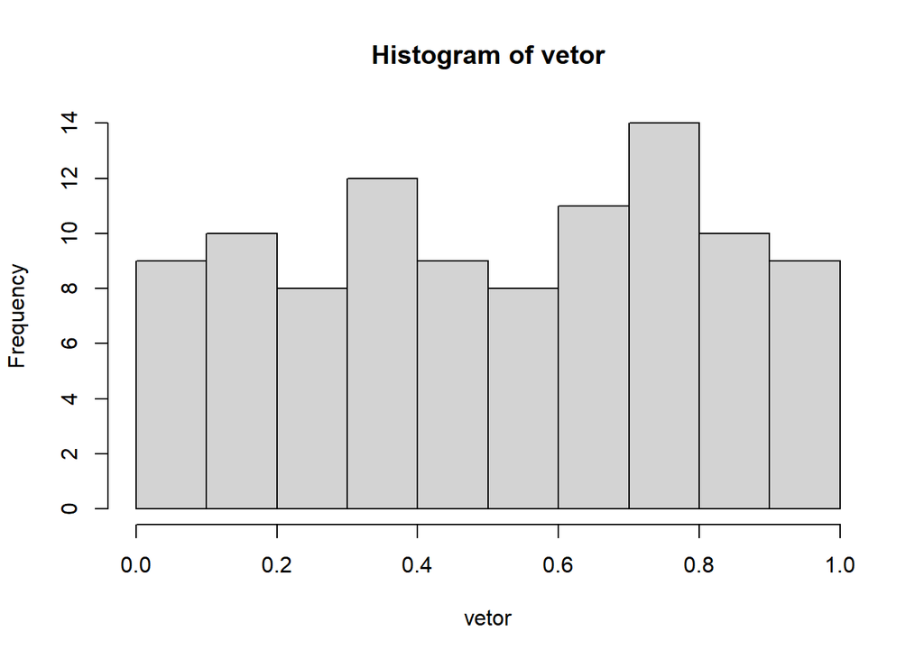

```r
vetor <- c(runif(100))
hist(vetor)
```

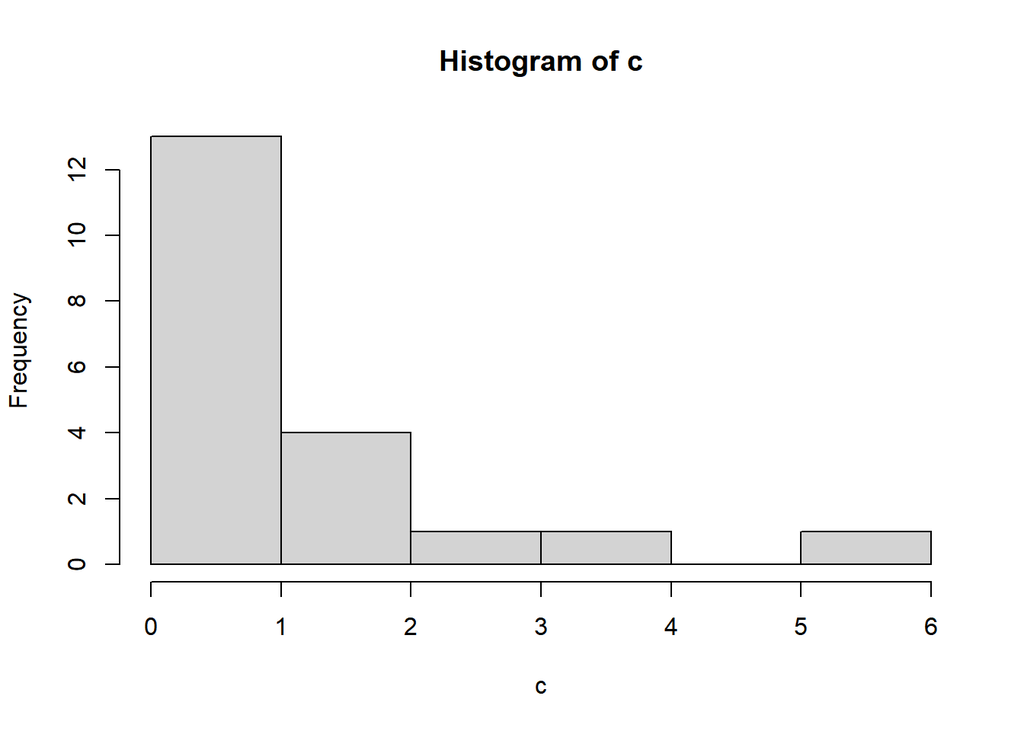

```r
n <- 20
c <- rexp(n, rate=1) #exponencial
hist(c)
```

```r
#geração de uma amostra aleatoria a partir de numeros pre-estabelecidos
x <- rnorm(50,10,2) #dados
sample(x, 3,re=TRUE) #sortear dentre os valores de x, "re" = replace (reposicao)
```

```
## [1]  9.294749 12.592490 10.478352
```

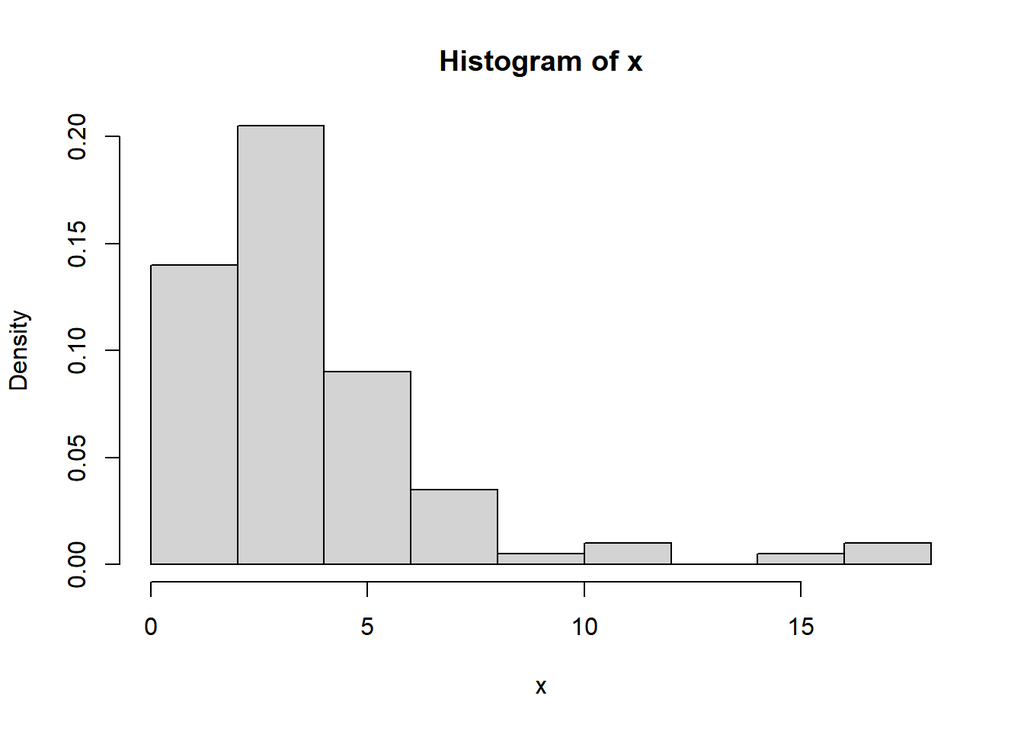

```r
require(stats)
set.seed(14)
x <- rchisq(100, df = 4)
hist(x, freq = FALSE, ylim = c(0, 0.2))
```

# 8 Leitura de arquivos .txt e .csv

Para copiar e colar direto de uma planílha use: `dados <- scan()`

Para importar arquivos em CSV use a função: `dados <- read.table(file="nomedoarquivo.csv",sep=",",dec=".",header=T)`

Para importar arquivos em TXT ou CSV selecionando o arquivo use as funções:  
`dados = read.table(file.choose(),header=T)` # para .txt  
`dados = read.table(file.choose(),header=T,sep=";",dec=".")` # para .csv

```r
dados <- read.table(file = "dados.txt", dec = ".", header = TRUE)
str(dados)
```

```
## 'data.frame':    12 obs. of  2 variables:
##  $ x: int  1 1 1 2 2 2 3 3 3 4 ...
##  $ y: int  2 4 5 3 7 4 7 9 6 7 ...
```

```r
names(dados)
```

```
## [1] "x" "y"
```

```r
class(dados)
```

```
## [1] "data.frame"
```

```r
attributes(dados)
```

```
## $names
## [1] "x" "y"
##
## $class
## [1] "data.frame"
##
## $row.names
##  [1]  1  2  3  4  5  6  7  8  9 10 11 12
```

```r
dados$y
```

```
##  [1]  2  4  5  3  7  4  7  9  6  7 11 10
```

```r
attach(dados)
y
```

```
## [1]  8  9 10 11 12
```

```r
x
```

```
##   [1]  1.5978282  3.3322985  3.0708725  2.5744330  6.7764815  2.8431800
##   [7]  4.7798098  4.2013360  3.6203090  2.5236530  4.8788430  2.3256201
##  [13] 10.1759434  2.8153700  0.6993601  2.7190979  2.3547836  4.3194835
##  [19]  4.3472164  3.7375415  5.0207279  4.1526903  2.1998894  3.6858705
##  [25]  4.5662583  3.8839883  3.9807882  0.9231033  3.1015811  2.8566852
##  [31]  1.8023261  1.2103736  7.4775292  2.9779815  2.1628704  1.3421543
##  [37]  3.2563822  1.5077376  2.5180166  1.4114212  0.8293910  7.6368595
##  [43] 16.6302925  2.2744868  1.7719876  0.4947304  1.7639663  5.3714693
##  [49]  1.6524618  7.0119613 16.9767672  3.2143291  1.6203122  6.5253462
##  [55]  1.0580171  4.8303820  2.8667919  3.6738743  2.4885080  8.0107460
##  [61]  2.5245266  1.0493424  3.0705241 15.4316212  0.3453903  7.0859825
##  [67]  1.7329998  2.0512795  1.3071472  5.6344011  3.9541127  2.6325437
##  [73]  0.3115387  5.2884788  1.3369640  5.0583443  3.4252851  4.1332816
##  [79]  2.9293921  1.4299040  3.0021506  1.5113295  1.5828157  2.5553601
##  [85]  1.2886474  3.9494644  1.4949560  2.0846314  3.1832552  5.2421299
##  [91]  4.3031409  1.8940315  1.9225727  3.9824388  2.8678671  5.6737469
##  [97] 11.4091608  4.0284655  3.3840483  6.8884167
```

```r
str(x)
```

```
##  num [1:100] 1.6 3.33 3.07 2.57 6.78 ...
```

## 8.1 Edição de dados

```r
dados <- edit(dados)
```

## 8.2 Dados nativos do R

Existem objetos no R que você pode “chamar” simplesmente digitando seu nome iris é um objeto na memória do R

```r
data(iris)
glimpse(iris)
```

```
## Rows: 150
## Columns: 5
## $ Sepal.Length <dbl> 5.1, 4.9, 4.7, 4.6, 5.0, 5.4, 4.6, 5.0, 4.4, 4.9, 5.4, 4.~
## $ Sepal.Width  <dbl> 3.5, 3.0, 3.2, 3.1, 3.6, 3.9, 3.4, 3.4, 2.9, 3.1, 3.7, 3.~
## $ Petal.Length <dbl> 1.4, 1.4, 1.3, 1.5, 1.4, 1.7, 1.4, 1.5, 1.4, 1.5, 1.5, 1.~
## $ Petal.Width  <dbl> 0.2, 0.2, 0.2, 0.2, 0.2, 0.4, 0.3, 0.2, 0.2, 0.1, 0.2, 0.~
## $ Species      <fct> setosa, setosa, setosa, setosa, setosa, setosa, setosa, s~
```

```r
head(iris)
```

```
##   Sepal.Length Sepal.Width Petal.Length Petal.Width Species
## 1          5.1         3.5          1.4         0.2  setosa
## 2          4.9         3.0          1.4         0.2  setosa
## 3          4.7         3.2          1.3         0.2  setosa
## 4          4.6         3.1          1.5         0.2  setosa
## 5          5.0         3.6          1.4         0.2  setosa
## 6          5.4         3.9          1.7         0.4  setosa
```

Podemos “chamar” as colunas (ou outras partes de obetos) pelo nome, usando o nome do objeto e um `$`  
O formato é sempre: `objeto$coluna`

```r
iris$Sepal.Length   #Aqui vemos apenas a coluna de comprimento da sépala
```

```
##   [1] 5.1 4.9 4.7 4.6 5.0 5.4 4.6 5.0 4.4 4.9 5.4 4.8 4.8 4.3 5.8 5.7 5.4 5.1
##  [19] 5.7 5.1 5.4 5.1 4.6 5.1 4.8 5.0 5.0 5.2 5.2 4.7 4.8 5.4 5.2 5.5 4.9 5.0
##  [37] 5.5 4.9 4.4 5.1 5.0 4.5 4.4 5.0 5.1 4.8 5.1 4.6 5.3 5.0 7.0 6.4 6.9 5.5
##  [55] 6.5 5.7 6.3 4.9 6.6 5.2 5.0 5.9 6.0 6.1 5.6 6.7 5.6 5.8 6.2 5.6 5.9 6.1
##  [73] 6.3 6.1 6.4 6.6 6.8 6.7 6.0 5.7 5.5 5.5 5.8 6.0 5.4 6.0 6.7 6.3 5.6 5.5
##  [91] 5.5 6.1 5.8 5.0 5.6 5.7 5.7 6.2 5.1 5.7 6.3 5.8 7.1 6.3 6.5 7.6 4.9 7.3
## [109] 6.7 7.2 6.5 6.4 6.8 5.7 5.8 6.4 6.5 7.7 7.7 6.0 6.9 5.6 7.7 6.3 6.7 7.2
## [127] 6.2 6.1 6.4 7.2 7.4 7.9 6.4 6.3 6.1 7.7 6.3 6.4 6.0 6.9 6.7 6.9 5.8 6.8
## [145] 6.7 6.7 6.3 6.5 6.2 5.9
```

# 9 Estatísticas dos dados

Média

```r
mean(iris$Sepal.Length)
```

```
## [1] 5.843333
```

Desvio padrão

```r
sd(iris$Sepal.Length)
```

```
## [1] 0.8280661
```

Calcular para cada espécie

```r
tapply(iris$Sepal.Length, iris$Species, mean)
```

```
##     setosa versicolor  virginica
##      5.006      5.936      6.588
```

```r
tapply(iris$Sepal.Length, iris$Species, sd)
```

```
##     setosa versicolor  virginica
##  0.3524897  0.5161711  0.6358796
```

Função tapply funciona sempre assim: `tapply(variável de interesse, variável categórica, função a ser calculada)`

```r
summary(iris)
```

```
##   Sepal.Length    Sepal.Width     Petal.Length    Petal.Width
##  Min.   :4.300   Min.   :2.000   Min.   :1.000   Min.   :0.100
##  1st Qu.:5.100   1st Qu.:2.800   1st Qu.:1.600   1st Qu.:0.300
##  Median :5.800   Median :3.000   Median :4.350   Median :1.300
##  Mean   :5.843   Mean   :3.057   Mean   :3.758   Mean   :1.199
##  3rd Qu.:6.400   3rd Qu.:3.300   3rd Qu.:5.100   3rd Qu.:1.800
##  Max.   :7.900   Max.   :4.400   Max.   :6.900   Max.   :2.500
##        Species
##  setosa    :50
##  versicolor:50
##  virginica :50
##
##
##
```

```r
tratamentos = rep(c(paste("T",1:5)),e=4)
str(tratamentos)
```

```
##  chr [1:20] "T 1" "T 1" "T 1" "T 1" "T 2" "T 2" "T 2" "T 2" "T 3" "T 3" ...
```

```r
resposta=c(100,120,110,90,
        150,145,149,165,
        150,144,134,139,
        220,206,210,210,
        266,249,248,260)
str(resposta)
```

```
##  num [1:20] 100 120 110 90 150 145 149 165 150 144 ...
```

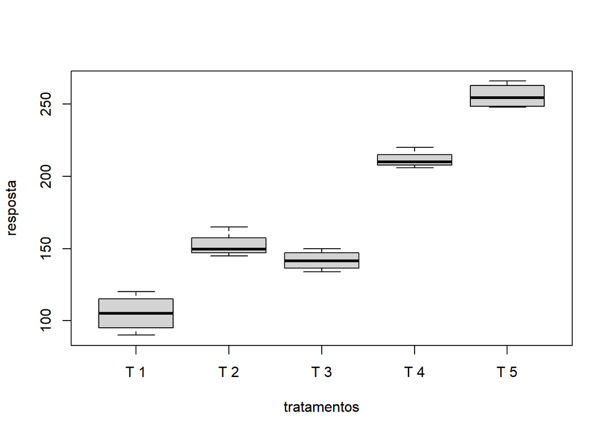

```r
# Média e Desvio-padrão (Por Tratamento)
media <- tapply(resposta,tratamentos, mean)
desvio <- tapply(resposta,tratamentos,sd)
boxplot(resposta~tratamentos)
```

# 10 Gráficos

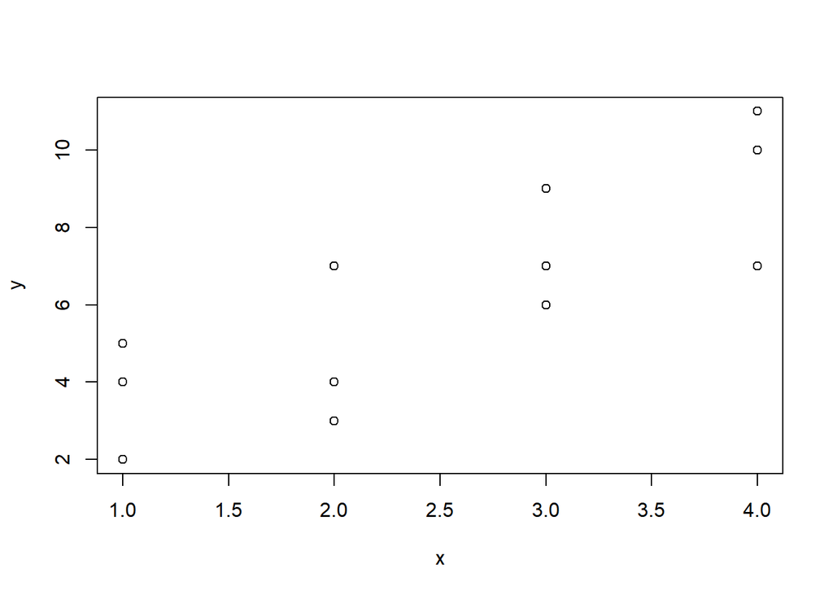

```r
plot(dados)
```

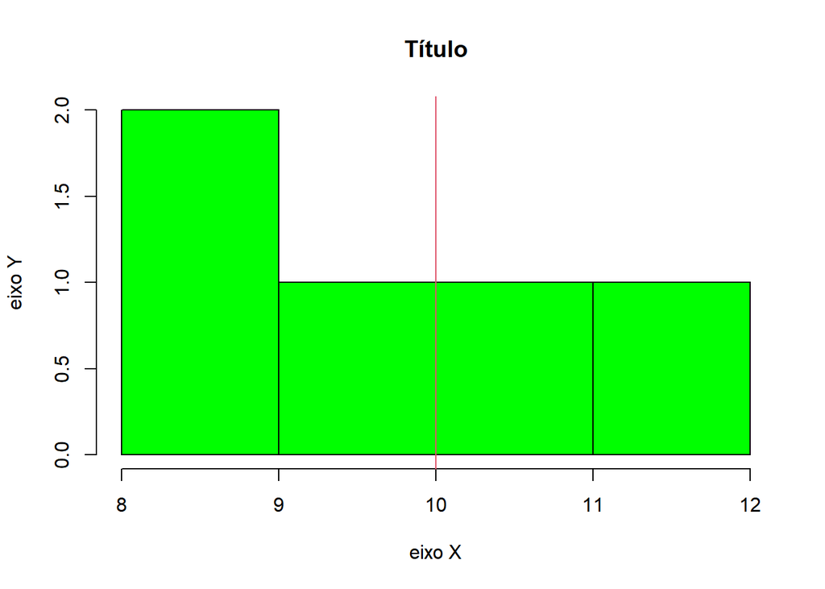

```r
#demo(graphics)
hist(y,xlab="eixo X",ylab="eixo Y",main="Título",col="green")
abline(v=mean(y),col=2)
```

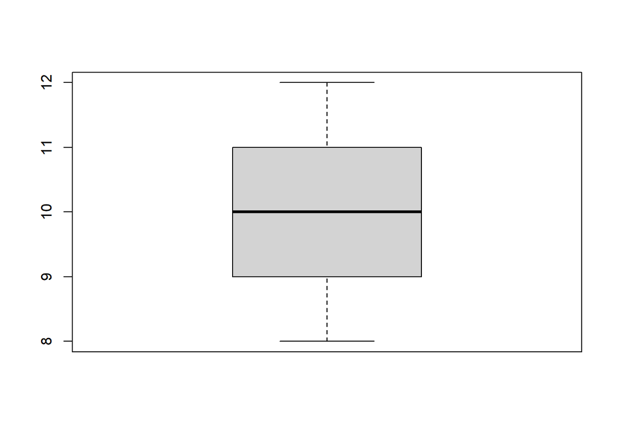

```r
boxplot(y)
```

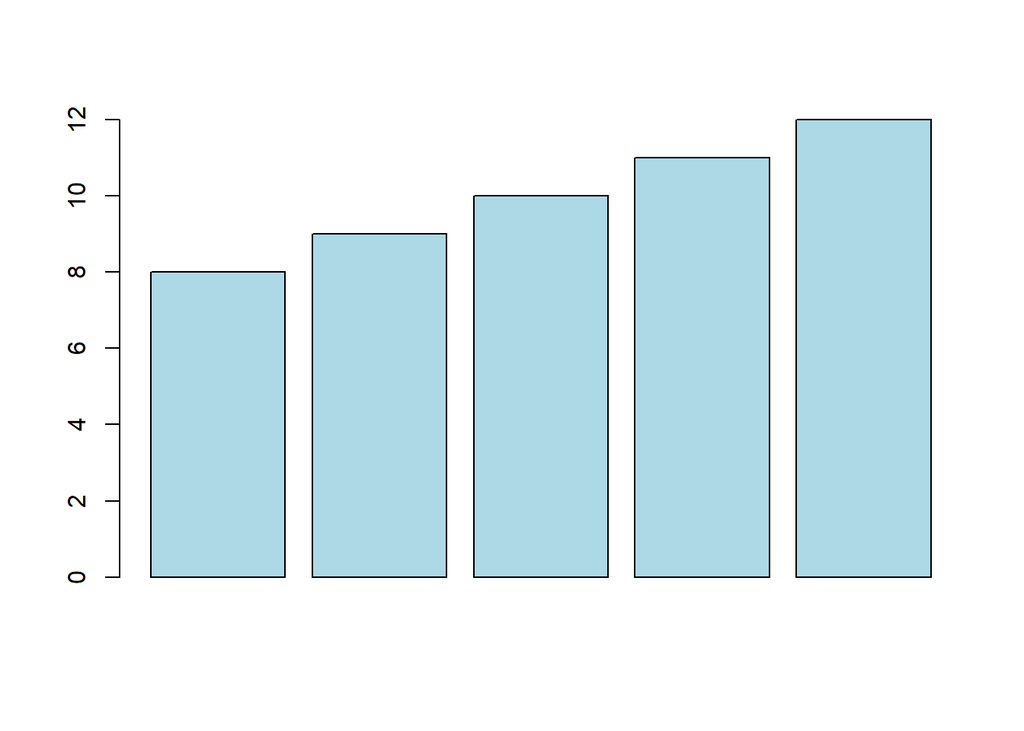

```r
barplot(y,col="lightblue")
```

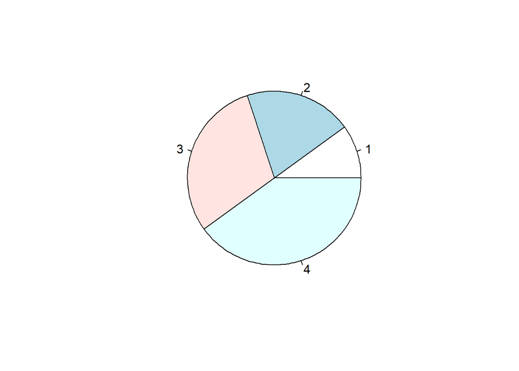

```r
pie(c(1:4))
```

## 10.1 Graficos múltiplos

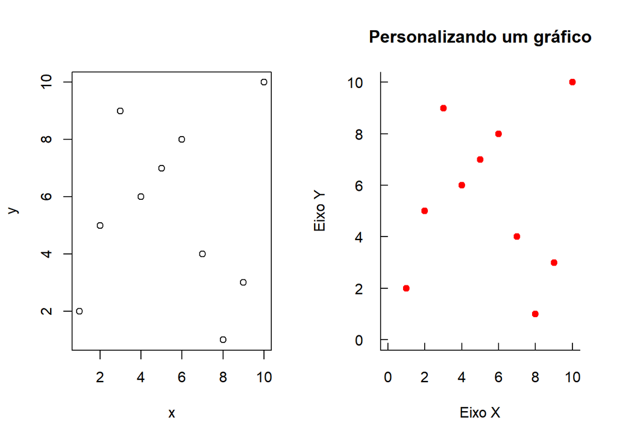

```r
par(mfrow=c(1,2))
x <- 1:10
y <- c(2,5,9,6,7,8,4,1,3,10)
plot(x,y)
plot(x,y, xlab="Eixo X", ylab="Eixo Y", main="Personalizando um gráfico",
xlim=c(0,10), ylim=c(0,10), col="red", pch=20, bg="blue", tcl=0.4, las=1, cex=1.5, bty="l")
```

## 10.2 Pacote `ggplot2`

Desenvolvido pelo Dr. Hadley Wickham, este pacote implementa uma nova maneira de criar gráficos, trazendo o conceito de camadas (layers) para a sintaxe do R.  
Carregando os dados

```r
levant <- read_excel("~/Introdução ao Software R/Semana Acadêmica Florestal 2021/levantamento.xlsx")
```

Visualizando os dados

```r
head(levant)
```

```
## # A tibble: 6 x 4
##   Parcela Especie                Idade   DAP
##     <dbl> <chr>                  <dbl> <dbl>
## 1       1 Araucaria angustifolia     6  12.1
## 2       1 Araucaria angustifolia     7  13.1
## 3       1 Araucaria angustifolia     8  29.9
## 4       1 Araucaria angustifolia     9  34.5
## 5       1 Araucaria angustifolia    10  45.9
## 6       1 Araucaria angustifolia    10  76.6
```

```r
names(levant)
```

```
## [1] "Parcela" "Especie" "Idade"   "DAP"
```

```r
glimpse(levant)
```

```
## Rows: 70
## Columns: 4
## $ Parcela <dbl> 1, 1, 1, 1, 1, 1, 1, 1, 1, 1, 1, 1, 1, 1, 1, 1, 1, 1, 1, 1, 1,~
## $ Especie <chr> "Araucaria angustifolia", "Araucaria angustifolia", "Araucaria~
## $ Idade   <dbl> 6, 7, 8, 9, 10, 10, 4, 5, 7, 8, 8, 4, 4, 5, 7, 4, 6, 8, 4, 8, ~
## $ DAP     <dbl> 12.1, 13.1, 29.9, 34.5, 45.9, 76.6, 10.0, 17.6, 21.9, 23.8, 24~
```

Fazendo um gráfico do DAP por Parcela

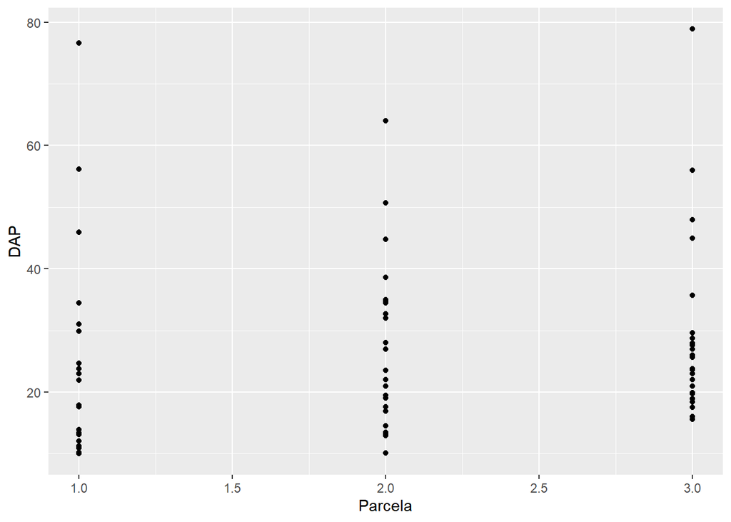

```r
ggplot(data=levant,aes(x=Parcela,y=DAP))+
  geom_point()
```

Fazendo um gráfico do DAP por Parcela

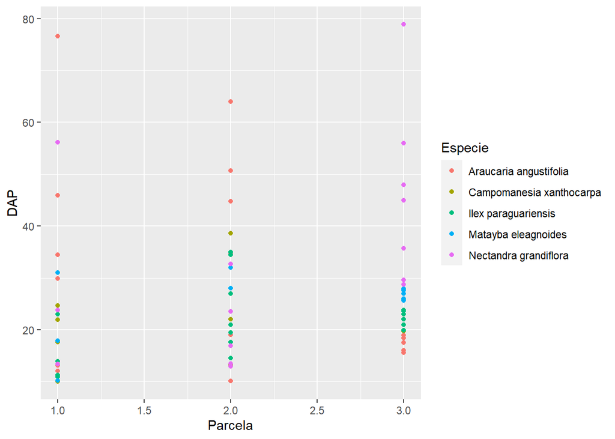

```r
ggplot(data=levant,aes(x=Parcela,y=DAP,
                       color = Especie))+
  geom_point()
```

Adicionando camadas

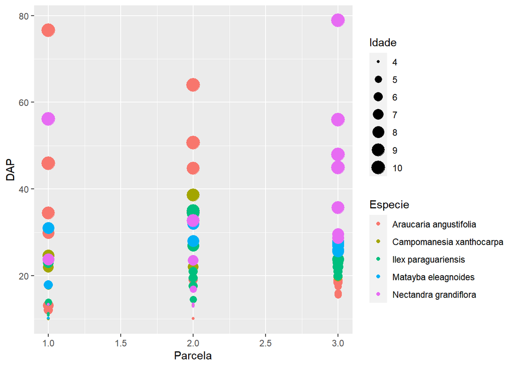

```r
ggplot(data=levant,aes(x=Parcela,y=DAP,
                       color = Especie,
                       size = Idade))+
  geom_point()
```

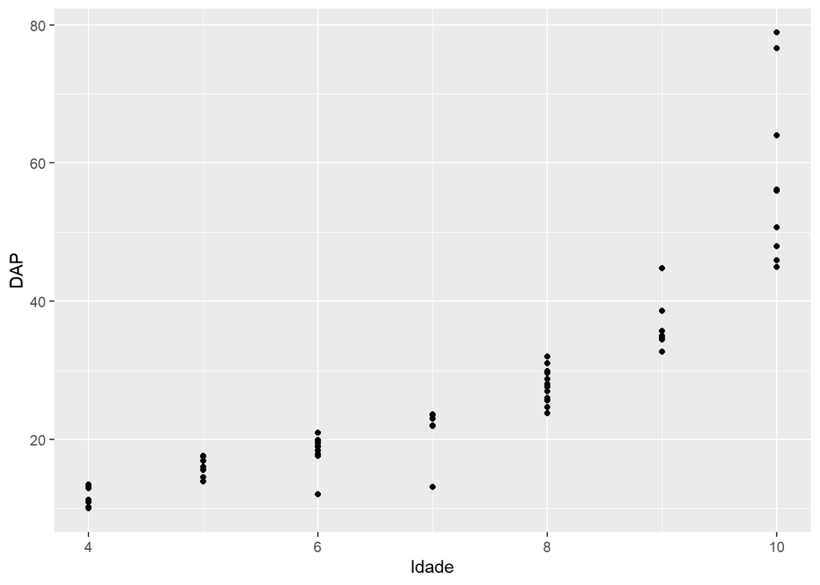

```r
ggplot(data=levant,aes(x=Idade,y=DAP))+
  geom_point()
```

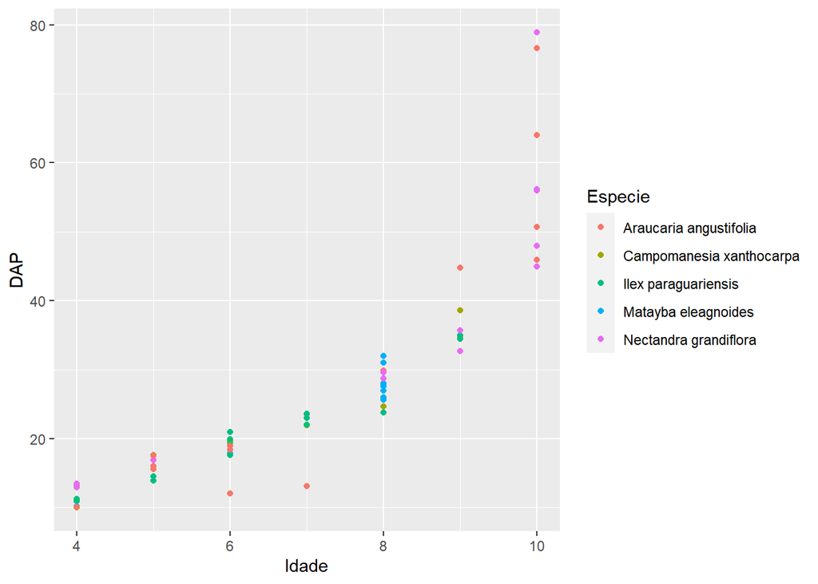

```r
ggplot(data=levant,aes(x=Idade,y=DAP,
                       color = Especie))+
  geom_point()
```

Adicionando camadas

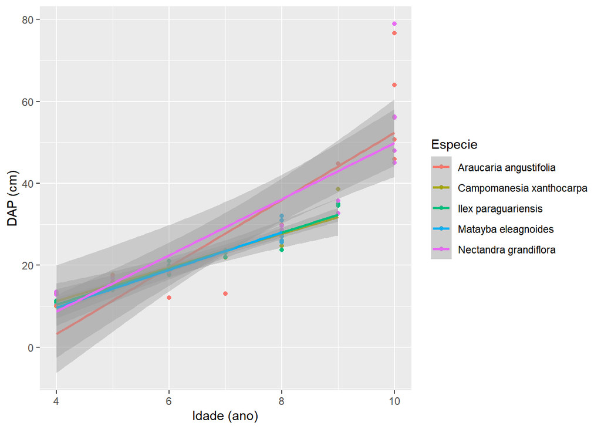

```r
ggplot(data=levant,aes(x=Idade,y=DAP,
                       color = Especie))+
  geom_point()+
  geom_smooth(method = "lm")+
  labs(x = "Idade (ano)", y = "DAP (cm)")
```

Vamos usar o pacote `gganatogram`

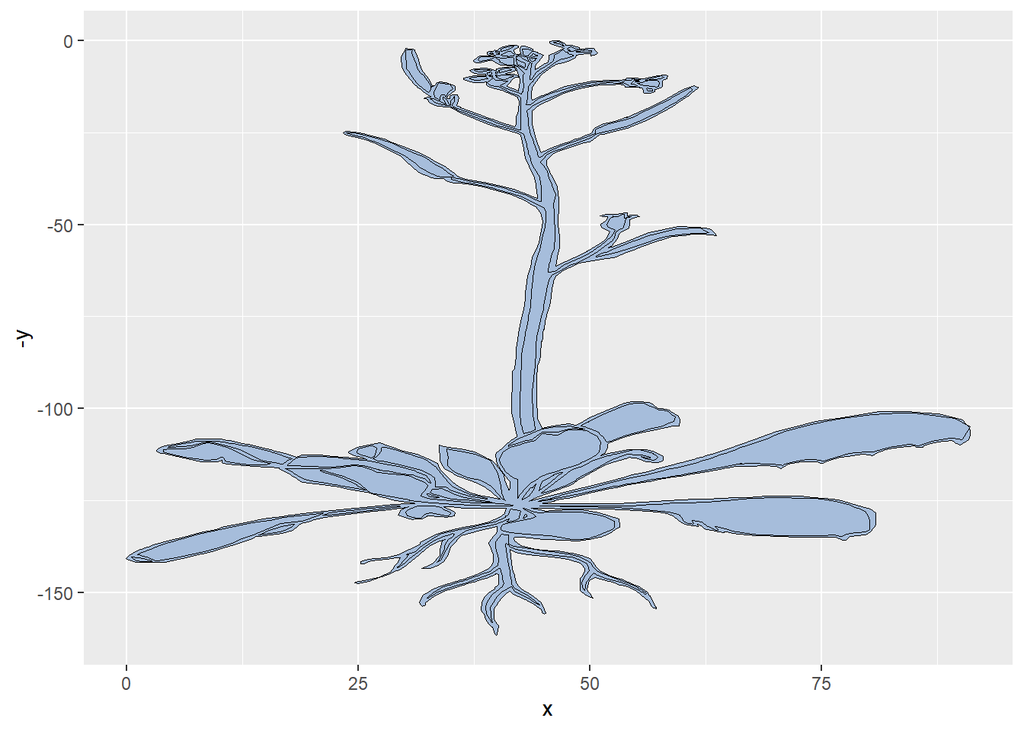

```r
#Use hgMale_key to find all tissues to plot
gganatogram(fillOutline='#a6bddb', organism='arabidopsis_thaliana',fill="colour")
```

```r
gganatogram::other_key[["arabidopsis_thaliana"]]
```

```
##         organ  type  colour     value
## 2        leaf other #E41A1C  7.967475
## 4        root other #377EB8 17.794112
## 9  PO_0009046 other #4DAF4A 11.409839
## 10 PO_0009046 other #984EA3 12.228996
## 11 PO_0009046 other #FF7F00  4.176849
## 12 PO_0009046 other #FFFF33 12.402561
## 13 PO_0009001 other #A65628  7.707830
## 14 PO_0009001 other #F781BF  2.845752
## 15 PO_0009001 other #999999 10.710045
```

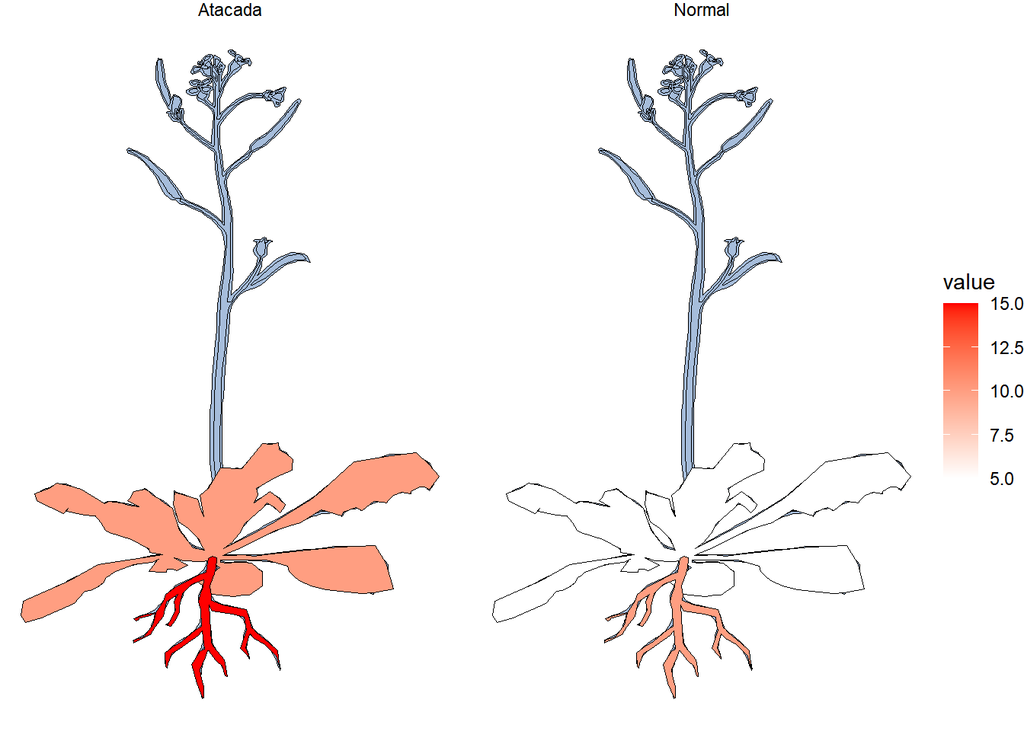

```r
comparar <- rbind(data.frame(organ = c("leaf", "root"),
                             colour = c("red", "orange"),
                             value = c(10, 15),
                             type = rep('Atacada', 2),
                             stringsAsFactors=F),
                  data.frame(organ = c("leaf", "root"),
                             colour = c("red", "orange"),
                             value = c(5, 10),
                             type = rep('Normal', 2),
                             stringsAsFactors=F))

gganatogram(data = comparar, fillOutline='#a6bddb', organism='arabidopsis_thaliana',fill="value")+
    theme_void() +
    facet_wrap(~type) +
    scale_fill_gradient(low = "white", high = "red")
```

# 11 Filosofica `Tidyverse`

É uma coleção de pacotes que tem filosofia, gramática e estruturas de dados em comum (criadas para um pacote trabalhar em conjunto com o outro além de que quando você aprende a usar um pacote, aprender a usar os outros pacotes do tidyverse se torna muito mais fácil. Facilita muito o trabalho.

Referência [Tidyverse](https://www.tidyverse.org/)

```r
library(tidyverse)
```

Diversas funções do `tidyverse` recebem uma `tibble` e retornam uma `tibble`, que são data frames com melhorias.  
A principal diferença entre `data.frame` e `tibble` é a forma em que o `tibble` é apresentada no console.

Carregando um conjunto de dados para o formato `tibble`

```r
madeira <- as.tibble(read.table(file.choose(),header=T))
madeira
```

```
## # A tibble: 80 x 7
##    Esp         Dens DensCarv    MV Cabono Cinza PoderCalor
##    <chr>      <dbl>    <dbl> <dbl>  <dbl> <dbl>      <dbl>
##  1 Urograndis 0.466    0.299  29.0   70.4 0.542      7277.
##  2 Urograndis 0.48     0.322  30.0   69.5 0.5        7247.
##  3 Urograndis 0.448    0.301  29.2   70.2 0.6        7269.
##  4 Urograndis 0.466    0.295  28.8   70.6 0.608      7283.
##  5 Urograndis 0.456    0.309  29.7   69.8 0.542      7257.
##  6 Urograndis 0.460    0.297  32.6   66.8 0.533      7158.
##  7 Urograndis 0.467    0.316  30.4   69.0 0.600      7229.
##  8 Urograndis 0.457    0.300  31.9   67.6 0.542      7182.
##  9 Urograndis 0.472    0.296  30.8   68.8 0.458      7223.
## 10 Urograndis 0.472    0.306  30.3   69.2 0.567      7235.
## # ... with 70 more rows
```

## 11.1 Uso do Operador Pipe `%>%`

Atalho: Control + Shift + M  
As funções do tidyverse foram projetadas para serem usadas com o operador `%>%`.  
Avalia o código do lado esquerdo e passa o resultado como o primeiro argumento do código do lado direito.

```r
x <- c(1.23, 2.45, 3.44, 3.24, 1.21)
sum(round(mean(x),2),5)
```

```
## [1] 7.31
```

```r
x %>% mean() %>% round(2) %>% sum(5)
```

```
## [1] 7.31
```

## 11.2 DPLYR

O pacote `dplyr` é voltado à manipular dados.  
Com essas funções temos uma flexibilidade incrível para transformar nossos dados.  
Estrutura: `funcao(base_dados, variaveis)`

### 11.2.1 Função `select()`

```r
names(madeira)
```

```
## [1] "Esp"        "Dens"       "DensCarv"   "MV"         "Cabono"
## [6] "Cinza"      "PoderCalor"
```

```r
madeira %>% select(Dens, PoderCalor)
```

```
## # A tibble: 80 x 2
##     Dens PoderCalor
##    <dbl>      <dbl>
##  1 0.466      7277.
##  2 0.48       7247.
##  3 0.448      7269.
##  4 0.466      7283.
##  5 0.456      7257.
##  6 0.460      7158.
##  7 0.467      7229.
##  8 0.457      7182.
##  9 0.472      7223.
## 10 0.472      7235.
## # ... with 70 more rows
```

```r
madeira %>% select(-Esp)
```

```
## # A tibble: 80 x 6
##     Dens DensCarv    MV Cabono Cinza PoderCalor
##    <dbl>    <dbl> <dbl>  <dbl> <dbl>      <dbl>
##  1 0.466    0.299  29.0   70.4 0.542      7277.
##  2 0.48     0.322  30.0   69.5 0.5        7247.
##  3 0.448    0.301  29.2   70.2 0.6        7269.
##  4 0.466    0.295  28.8   70.6 0.608      7283.
##  5 0.456    0.309  29.7   69.8 0.542      7257.
##  6 0.460    0.297  32.6   66.8 0.533      7158.
##  7 0.467    0.316  30.4   69.0 0.600      7229.
##  8 0.457    0.300  31.9   67.6 0.542      7182.
##  9 0.472    0.296  30.8   68.8 0.458      7223.
## 10 0.472    0.306  30.3   69.2 0.567      7235.
## # ... with 70 more rows
```

```r
madeira %>% select(-Esp) %>% cor() %>% round(2)
```

```
##             Dens DensCarv    MV Cabono Cinza PoderCalor
## Dens        1.00     0.91 -0.10   0.02  0.67       0.02
## DensCarv    0.91     1.00 -0.09   0.00  0.75       0.00
## MV         -0.10    -0.09  1.00  -0.99 -0.17      -0.99
## Cabono      0.02     0.00 -0.99   1.00  0.05       1.00
## Cinza       0.67     0.75 -0.17   0.05  1.00       0.05
## PoderCalor  0.02     0.00 -0.99   1.00  0.05       1.00
```

### 11.2.2 Função `arrange()`

Orderna linhas  
Se a variável for categórica ordena por ordem alfabética  
Se a variável for numérica ordena do menor para o maior  
Se a varíavel for um fator, ordena pelos níveis do fator

```r
madeira %>% arrange(Esp,desc(PoderCalor))
```

```
## # A tibble: 80 x 7
##    Esp            Dens DensCarv    MV Cabono Cinza PoderCalor
##    <chr>         <dbl>    <dbl> <dbl>  <dbl> <dbl>      <dbl>
##  1 camaldulensis 0.520    0.350  18.7   80.4 0.917      7608.
##  2 camaldulensis 0.523    0.352  18.9   80.2 0.95       7601.
##  3 camaldulensis 0.509    0.339  19.2   79.5 1.23       7581.
##  4 camaldulensis 0.505    0.328  19.8   79.4 0.842      7576.
##  5 camaldulensis 0.512    0.342  19.8   79.4 0.85       7576.
##  6 camaldulensis 0.479    0.311  19.9   79.3 0.792      7572.
##  7 camaldulensis 0.505    0.332  20.0   79.2 0.8        7570.
##  8 camaldulensis 0.494    0.326  20.1   79.1 0.758      7567.
##  9 camaldulensis 0.542    0.362  20.3   78.9 0.792      7560.
## 10 camaldulensis 0.518    0.327  20.9   78.0 1.17       7528.
## # ... with 70 more rows
```

### 11.2.3 Função `filter()`

Filtra linhas

```r
madeira %>% filter(Esp=="citriodora")
```

```
## # A tibble: 20 x 7
##    Esp         Dens DensCarv    MV Cabono Cinza PoderCalor
##    <chr>      <dbl>    <dbl> <dbl>  <dbl> <dbl>      <dbl>
##  1 citriodora 0.592    0.441  26.6   71.9 1.52       7327.
##  2 citriodora 0.601    0.452  25.7   73.2 1.02       7371.
##  3 citriodora 0.572    0.423  27.8   70.6 1.65       7282.
##  4 citriodora 0.594    0.444  26.1   72.5 1.42       7345.
##  5 citriodora 0.614    0.449  26.7   71.8 1.53       7323.
##  6 citriodora 0.625    0.485  26.6   72.2 1.22       7336.
##  7 citriodora 0.604    0.457  26.6   72.1 1.3        7334.
##  8 citriodora 0.578    0.474  26.4   72.2 1.45       7336.
##  9 citriodora 0.583    0.434  27.8   70.6 1.54       7284.
## 10 citriodora 0.540    0.41   26.7   71.3 2.02       7307.
## 11 citriodora 0.576    0.460  23.5   74.6 1.92       7415.
## 12 citriodora 0.569    0.458  21.7   76.8 1.51       7491.
## 13 citriodora 0.604    0.492  22.1   76.0 1.90       7463.
## 14 citriodora 0.575    0.467  21.8   76.2 1.92       7471.
## 15 citriodora 0.576    0.473  23.4   74.7 1.95       7420.
## 16 citriodora 0.583    0.484  21.2   77.8 0.956      7524.
## 17 citriodora 0.562    0.444  20.9   77.6 1.52       7515.
## 18 citriodora 0.568    0.469  22.2   75.7 2.09       7454.
## 19 citriodora 0.603    0.533  21.9   76.5 1.55       7480.
## 20 citriodora 0.562    0.449  21.9   76.6 1.47       7483.
```

```r
madeira %>% filter(Esp=="citriodora", Dens >= 0.6)
```

```
## # A tibble: 6 x 7
##   Esp         Dens DensCarv    MV Cabono Cinza PoderCalor
##   <chr>      <dbl>    <dbl> <dbl>  <dbl> <dbl>      <dbl>
## 1 citriodora 0.601    0.452  25.7   73.2  1.02      7371.
## 2 citriodora 0.614    0.449  26.7   71.8  1.53      7323.
## 3 citriodora 0.625    0.485  26.6   72.2  1.22      7336.
## 4 citriodora 0.604    0.457  26.6   72.1  1.3       7334.
## 5 citriodora 0.604    0.492  22.1   76.0  1.90      7463.
## 6 citriodora 0.603    0.533  21.9   76.5  1.55      7480.
```

### 11.2.4 Função `mutate()`

Modifica e cria colunas

```r
madeira %>%
  mutate(
    DensCarvP = DensCarv/Dens*100
  )
```

```
## # A tibble: 80 x 8
##    Esp         Dens DensCarv    MV Cabono Cinza PoderCalor DensCarvP
##    <chr>      <dbl>    <dbl> <dbl>  <dbl> <dbl>      <dbl>     <dbl>
##  1 Urograndis 0.466    0.299  29.0   70.4 0.542      7277.      64.2
##  2 Urograndis 0.48     0.322  30.0   69.5 0.5        7247.      67.0
##  3 Urograndis 0.448    0.301  29.2   70.2 0.6        7269.      67.4
##  4 Urograndis 0.466    0.295  28.8   70.6 0.608      7283.      63.2
##  5 Urograndis 0.456    0.309  29.7   69.8 0.542      7257.      67.8
##  6 Urograndis 0.460    0.297  32.6   66.8 0.533      7158.      64.7
##  7 Urograndis 0.467    0.316  30.4   69.0 0.600      7229.      67.6
##  8 Urograndis 0.457    0.300  31.9   67.6 0.542      7182.      65.6
##  9 Urograndis 0.472    0.296  30.8   68.8 0.458      7223.      62.7
## 10 Urograndis 0.472    0.306  30.3   69.2 0.567      7235.      64.9
## # ... with 70 more rows
```

### 11.2.5 Função `summarise()`

Calcula estatísticas descritivas: média, soma, desvio padrão, frequência absoluta

```r
madeira %>%
  summarise(
    med_Dens = mean(Dens),
    sd_Dens = sd(Dens),
    n = n()
  )
```

```
## # A tibble: 1 x 3
##   med_Dens sd_Dens     n
##      <dbl>   <dbl> <int>
## 1    0.523  0.0496    80
```

### 11.2.6 Função `group_by()`

Função de agrupamento para aplicar outras funções

```r
madeira %>%
  group_by(Esp) %>%
  summarise(
    med_Dens = mean(Dens),
    sd_Dens = sd(Dens),
    n = n()
  ) %>% ungroup()
```

```
## # A tibble: 4 x 4
##   Esp           med_Dens sd_Dens     n
##   <chr>            <dbl>   <dbl> <int>
## 1 camaldulensis    0.513  0.0171    20
## 2 citriodora       0.584  0.0205    20
## 3 Urograndis       0.465  0.0178    20
## 4 Urophylla        0.531  0.0390    20
```

Obs: É importante lembrar de usar a função `ungroup()` para desagrupar os dados se quisermos continuar fazendo mudanças na base

# 12 Pacote `florestal`

As funções retornam parâmetros de amostragem para inventários florestais com tabelas e gráficos. Os métodos utilizados no pacote referem-se a [Pellico & Brena (1997)](https://bit.ly/2BDbHJI).  
[Resultados para Inventários Florestais](https://github.com/igorcobelo/florestal/)

```r
remotes::install_github("igorcobelo/florestal")
library(florestal)
```

```r
data("simple1")
head(simple1)
```

```
##   Plot Individual               Specie Height (m) Diameter (cm)
## 1    1          1 Cariocar braziliense         10            18
## 2    1          1 Cariocar braziliense         10            16
## 3    1          1 Cariocar braziliense         10            17
## 4    1          1 Cariocar braziliense         10            18
## 5    1          2     Qualya parvifora         14            17
## 6    1          3    Magonia pubescens         12            19
```

```r
glimpse(simple1)
```

```
## Rows: 120
## Columns: 5
## $ Plot            <dbl> 1, 1, 1, 1, 1, 1, 1, 1, 1, 1, 1, 1, 1, 1, 1, 1, 1, 1, ~
## $ Individual      <dbl> 1, 1, 1, 1, 2, 3, 3, 4, 5, 6, 7, 8, 9, 10, 11, 12, 13,~
## $ Specie          <chr> "Cariocar braziliense", "Cariocar braziliense", "Cario~
## $ `Height (m)`    <dbl> 10, 10, 10, 10, 14, 12, 12, 13, 12, 10, 14, 14, 13, 11~
## $ `Diameter (cm)` <dbl> 18, 16, 17, 18, 17, 19, 19, 16, 15, 15, 16, 17, 18, 16~
```

```r
IF_e1 <- indvol(est1[est1$Stratum==1,],mens="strata",veg="cerradoss_df")
IF_e2 <- indvol(est1[est1$Stratum==2,],mens="strata",veg="matas>10_df")
est2 <- rbind(IF_e1,IF_e2)
head(est2)
```

```
##   Stratum Plot Individual                  Specie  h Diameter (cm) Volume (m3)
## 1       1    1          1    Cariocar braziliense 10      34.53983   0.6680800
## 2       1    1          2        Qualya parvifora 14      17.00000   0.2139756
## 3       1    1          3       Magonia pubescens 12      26.87006   0.4694444
## 4       1    1          4 Stenocalyx dysentericus 13      16.00000   0.1779968
## 5       1    1          5      Solanum lycocarpum 12      15.00000   0.1462950
## 6       1    1          6 Stenocalyx dysentericus 10      15.00000   0.1260000
```

# 13 Indicações de materiais e referências utilizadas

[Ciência de Dados com R - Introdução. CSV,CONF](https://cdr.ibpad.com.br/)

[Ciência de Dados em R - CURSO-R](https://livro.curso-r.com/index.html)

[GUIA RÁPIDO DO USUÁRIO R.](http://www.leg.ufpr.br/~walmes/cursoR/guia_rapido_R.pdf)

[MENSURAÇÃO FLORESTAL](http://www.mensuracaoflorestal.com.br/)

[Resultados para Inventários Florestais](https://github.com/igorcobelo/florestal/)

[RIBEIRO JR, P. J. “R”eflexões: um pouco de história e experiências com o R.](https://youtu.be/fnGvDEkjZy0)

[SOUZA, D. V.; OLIVEIRA, T. W. G.; PIVA, L. R. O.; SANTOS, J. X.; SANQUETTA, C. R.; CORTE, A. P. D. Introdução ao R: aplicações florestais. 2018. 136 p.](http://www.centralflorestal.com.br/2018/08/livro-disponivel-sobre-uso-do-software.html)

[ZEVIANI, W. Uso da linguagem R para análise de dados de inventário florestal. 2020.](http://leg.ufpr.br/~walmes/talks/linguagem-r-para-inventario-florestal.pdf)